# Observer’s paradox: data from the interviews in the Ustja River Basin Corpus

## Introduction

Paradox formulated in Labov (1972):

> We are then left with the Observers Paradox: theaim of linguistic research in the community must beto find out how people talk when they are not being systematically observed; yet we can only obtain this data by systematic observation.

## Introduction

**Dialectness** – probability of occurence of a dialect variable across time

## Data

- Data obtained from Ustja River Basin Corpus (see Waldenfels, Daniel, and Dobrushina (2014) ) – corpus of dialects of the Russian North
- The corpora was annotated by different people for the Daniel et al. (n.d.) project. All the variables were categorized only as dialect or standart
- Sample of 178 interviews
- 135 different speakers

## Data

Used data contains following datafields:

- Speaker – individual code of the speaker
- Year of birth – year of birth of the speaker
- Gender – gender of the speaker
- Audio – name of the audio file containing the recording (as the data contains splitted files this field will be useful for gluing the cuted files together)
- Context – context, in which certain variable was pronounced
- Token – the exact token, which contains the variable
- Realization class – dialectal or standard
- Variable – exact variable used
- Position – position in the interview (in milliseconds)

## Data

- Interviewer – the person who has taken the following interview
- Length – length of the following audio file

## Data

Year of birth distribution:

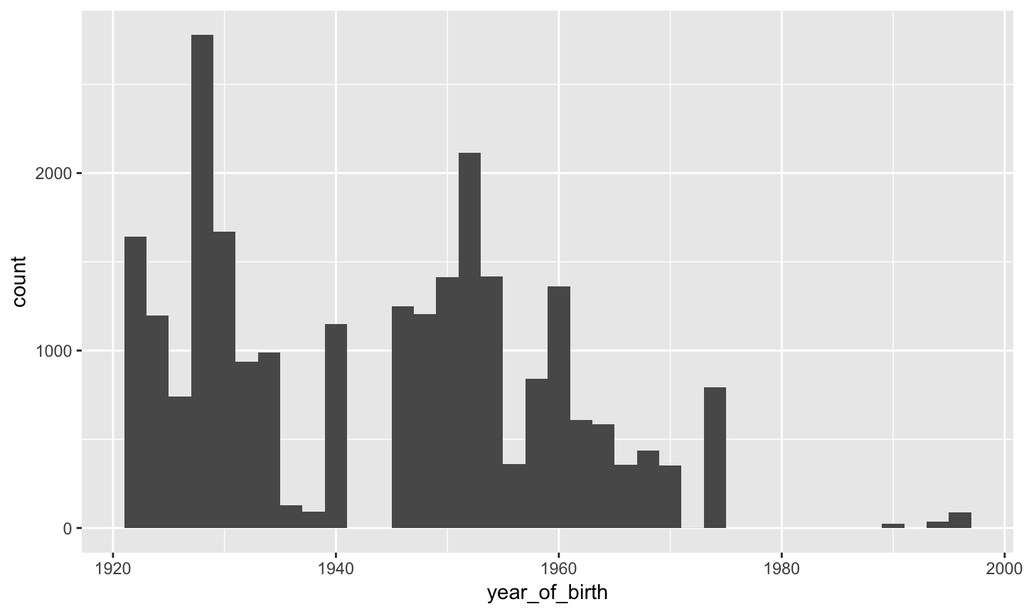

## Data

- Distribution of variable quantities:

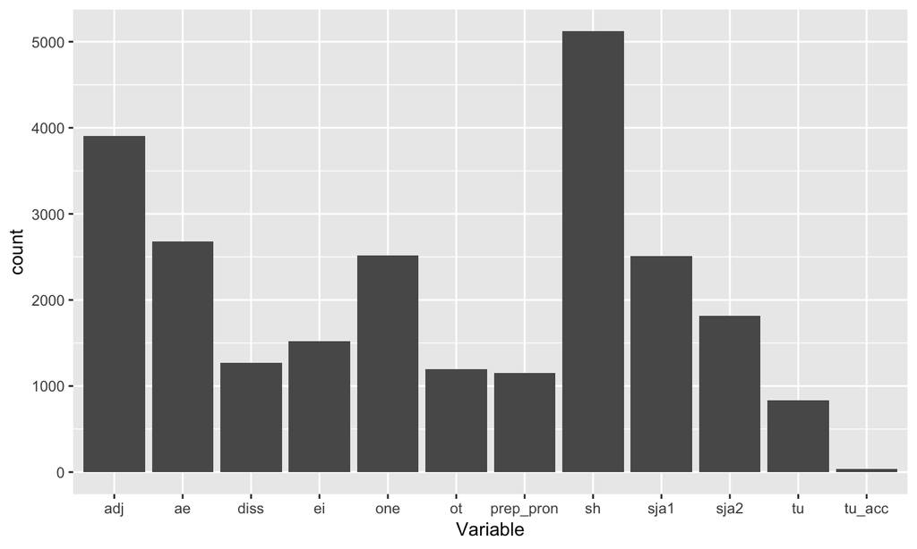

## Data

Distribution of lengths:

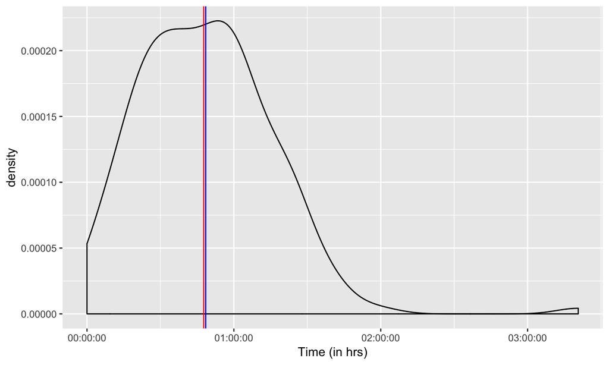

## Data

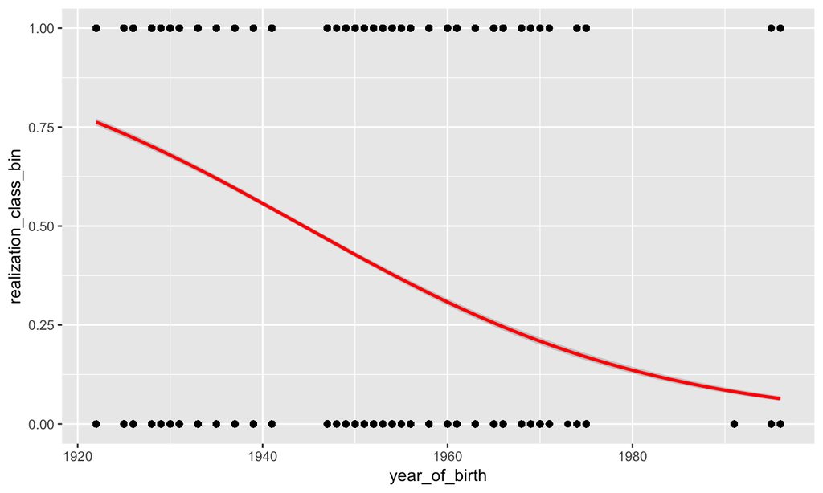

## Hypothesis

**Realization class is influnced by the position, which results in changement in dialectness towards the end of the interview, because speakers get distracted towards the end and start lossing self caution.**

## Preliminary analysis

Causal relations using the PC-algorithm (see Spirtes et al. (2000), alpha=0.00001):

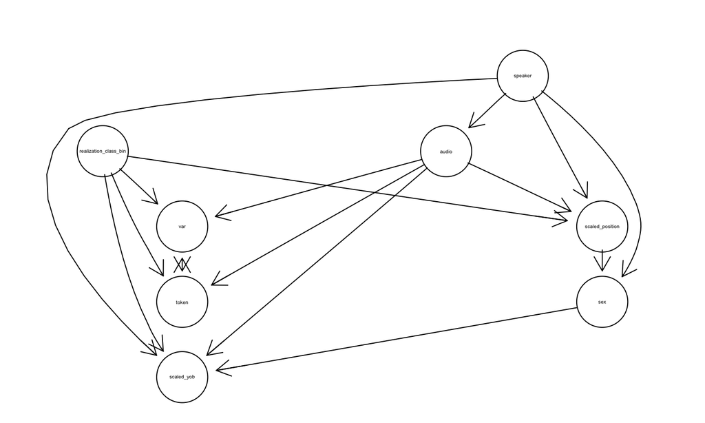

## Analysis

Generalized linear model with mixed effects. Overall formula:

- realization_class ~ position + (1 | var) + (1 | sex/speaker) + (1 | year of birth) + (1 | length/audio) + (1 | token) - 1

## Analysis

Check different subsets on the singnificance of the position:

- All variables

– ae – diss – etc.

- Year of birth

– < 1940 – 1940-1960 – > 1960

- Se… Gender

– male – female

## Analysis

Understand in which subset the position is important.

Different formulae for different subsets:

- Variables – realization_class ~ position + (1 | sex/speaker) + (1 | year of birth) + (1 | length/audio) + (1 | token) - 1
- Year of birth groups – realization_class ~ position + (1 | var) + (1 | sex/speaker) + (1 | length/audio) + (1 | token) - 1
- Gender – realization_class ~ position + (1 | var) + (1 | speaker) + (1 | year of birth) + (1 | length/audio) + (1 | token) - 1

## Analysis

P-values for each variable:

| Var | sh | adj | sja1 | sja2 | one | ei | diss | ae | tu | prep_pron |
| --- | --- | --- | --- | --- | --- | --- | --- | --- | --- | --- |
| p-value | 2.05e-05 (~0.41) | 0.389 | 0.454 | 0.0758 | 0.48 | 0.0965 | 0.256 | <2e-16 (~0.13) | 0.544 | 0.0164 (~0.25) |

However, ae – did not converge

## Analysis

SH:

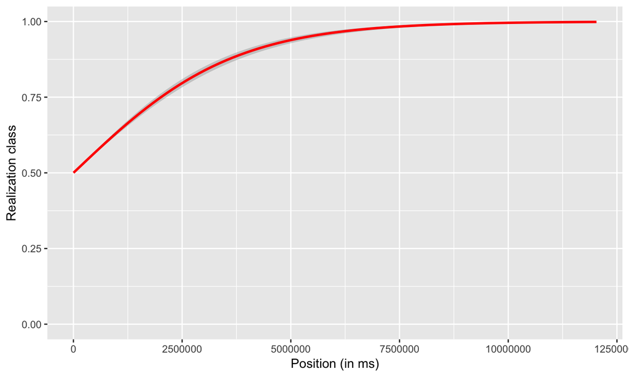

## Analysis

AE:

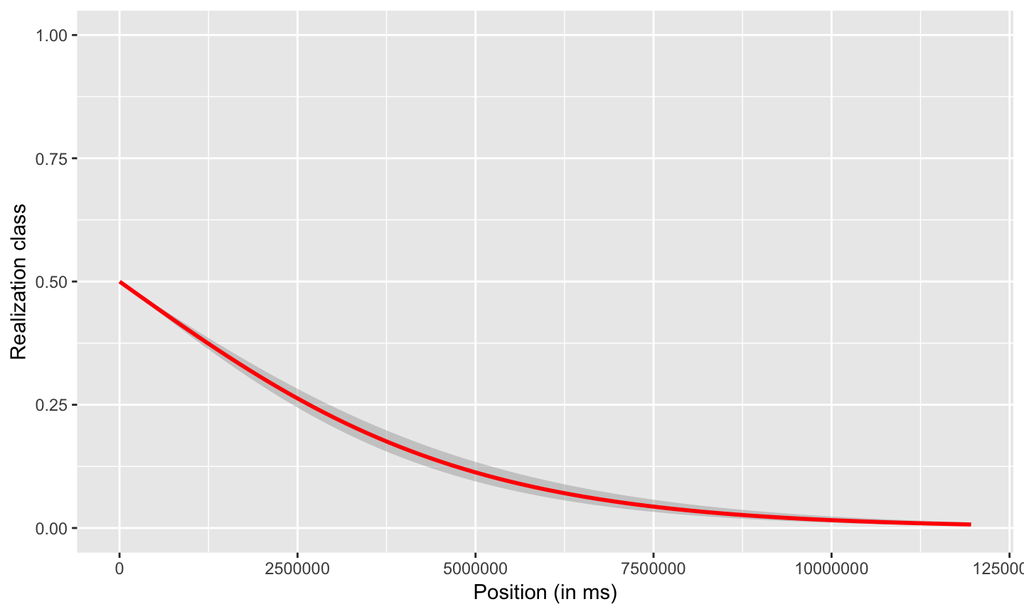

## Analysis

AE (all the files):

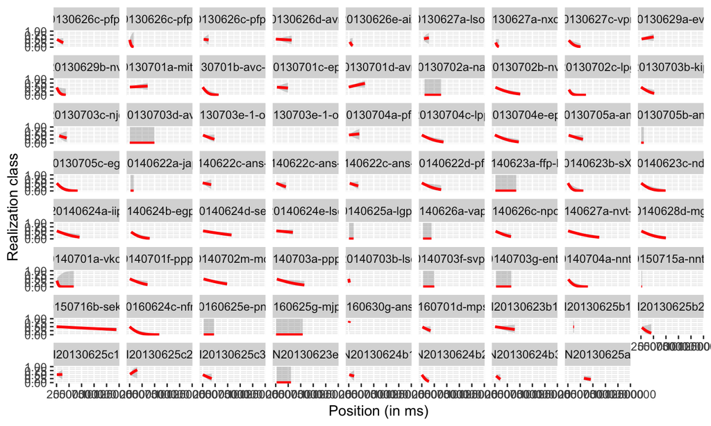

## Analysis

PREP_PRON

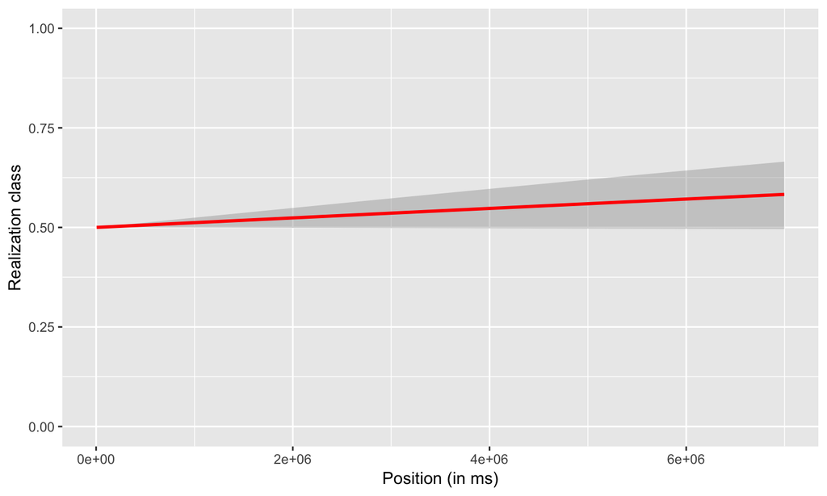

## Analysis

Age group:

| Group | < 1940 | 1940-1960 | > 1960 |
| --- | --- | --- | --- |
| p-value | 0.302 | 0.0246 (0.08280) | 0.437 |

## Analysis

1940-1960

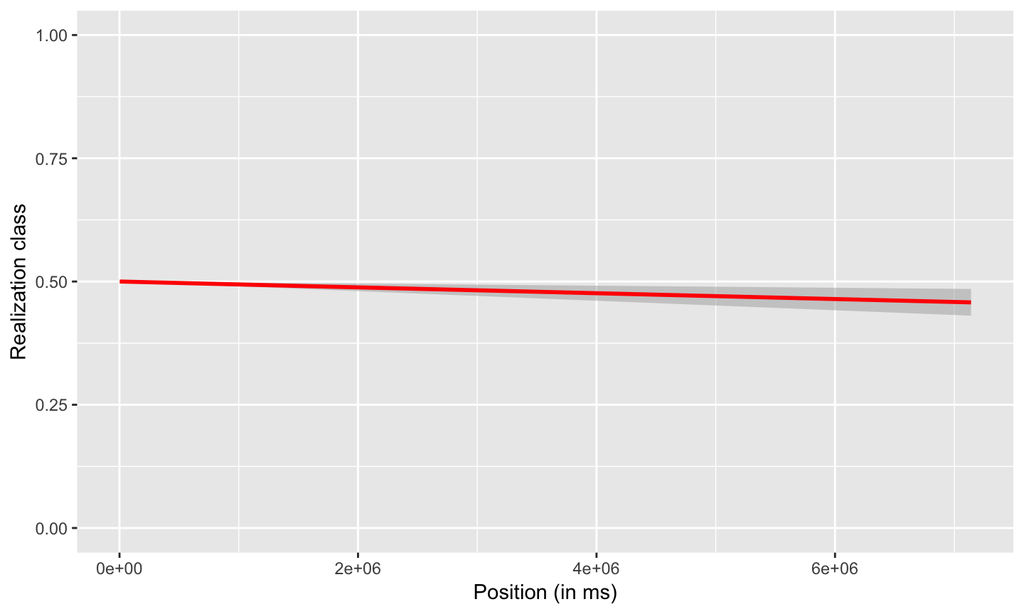

## Analysis

Gender:

| Group | male | female |
| --- | --- | --- |
| p-value | 0.00579 (0.15378) | 0.788 |

male – p<0.5, positive slope

## Analysis

Male:

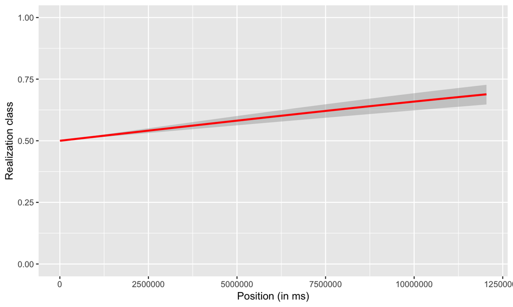

## Preliminary summary

- There is no significance on the “global” level
- If there is a trend in the subsets, it is usually positive (from less dialect in the beggining to more in the end). **But**, ae and 1940-1960 – negative
- This can may be be linked with the fact that the speakers are getting more concentrated after some time and they start to use only the dialect variants

## If not position, then what?

LogisticRegressionCV from sklearn Python-package (cv=10, max_iter=1000)

Metric: roc-auc score

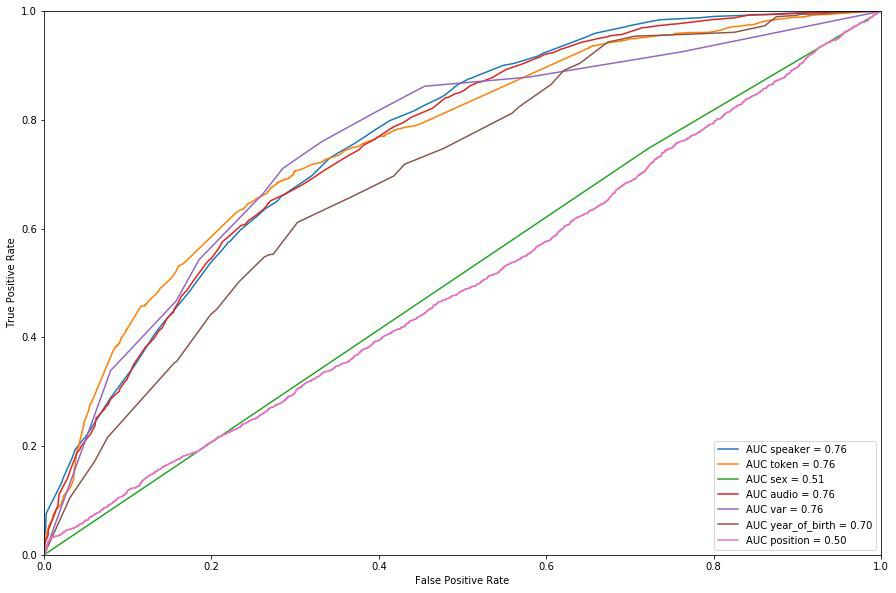

## If not position, then what?

| category | speaker | token | sex | audio | var | year of birth | position |
| --- | --- | --- | --- | --- | --- | --- | --- |
| roc | 0.765 | 0.767 | 0.513 | 0.760 | 0.758 | 0.704 | 0.498 |

\

token > speaker > audio > variable > year of birth > sex > position

## Litterature

Daniel, M., Kazakova P., A. Ter-Avanesova, R. von Waldenfels, E. Gerasimenko, D. Ignatenko, E. Makhlina, et al. n.d. “Dialect Loss in the Russian North: Modeling Change Across Variables.”

Labov, William. 1972. *Sociolinguistic Patterns*. 4. University of Pennsylvania Press.

Spirtes, Peter, Clark N Glymour, Richard Scheines, David Heckerman, Christopher Meek, Gregory Cooper, and Thomas Richardson. 2000. *Causation, Prediction, and Search*. MIT press.

Waldenfels, R. von, M. Daniel, and N. Dobrushina. 2014. “Why Standard Orthography? Building the Ustya River Basin Corpus, an Online Corpus of a Russian Dialect.” In *Computational Linguistics and Intellectual Technologies. Papers from the Annual International Conference Dialogue*, 13:720–28. 1.